# R Notebook

# Chapter 16 Statistical Models

“All models are wrong, but some are useful.” –George E. P. Box

Their performance in the 2008 election brought FiveThirtyEight to the attention of political pundits and TV personalities.

In this chapter we will demonstrate how poll aggregators, such as FiveThirtyEight, collected and combined data reported by different experts to produce improved predictions.

## 16.1 Poll Aggregators

A few weeks before the 2012 election Nate Silver was giving Obama a 90% chance of winning. How was Mr. Silver so confident?

We will use a Monte Carlo simulation!

We generate results for 12 polls taken the week before the election. We mimic sample sizes from actual polls and construct and report 95% confidence intervals for each of the 12 polls. We save the results from this simulation in a data frame and add a poll ID column.

```r
library(tidyverse)
library(dslabs)
d <- 0.039
Ns <- c(1298, 533, 1342, 897, 774, 254, 812, 324, 1291, 1056, 2172, 516)
p <- (d + 1) / 2

polls <- map_df(Ns, function(N) {
  x <- sample(c(0,1), size=N, replace=TRUE, prob=c(1-p, p))
  x_hat <- mean(x)
  se_hat <- sqrt(x_hat * (1 - x_hat) / N)
  list(estimate = 2 * x_hat - 1,
    low = 2*(x_hat - 1.96*se_hat) - 1,
    high = 2*(x_hat + 1.96*se_hat) - 1,
    sample_size = N)
}) %>% mutate(poll = seq_along(Ns))
```

All 12 polls report confidence intervals that include the election night result. However, all 12 polls also include 0 as well.

Poll aggregators, such as Nate Silver, realized that by combining the results of different polls you could greatly improve precision.

Reconstruct what we would have obtained had we made one large poll with:

```r
sum(polls$sample_size)
```

```
[1] 11269
```

participants.

Estimate of the spread: $d$

```r
d_hat <- polls %>%
  summarize(avg = sum(estimate*sample_size) / sum(sample_size)) %>%
  pull(avg)
```

Once we have an estimate of $d$, we can construct an estimate for the proportion voting for Obama, which we can then use to estimate the standard error. Once we do this, we see that our margin of error is 0.018.

Thus, we can predict that the spread will be 3.1 plus or minus 1.8, which not only includes the actual result we eventually observed on election night, but is quite far from including 0.

Of course, The actual data science exercise of forecasting elections is much more complicated and it involves modeling.

Since the 2008 elections, other organizations have started their own election forecasting group that, like Nate Silver’s, aggregates polling data and uses statistical models to make predictions. In 2016, forecasters underestimated Trump’s chances of winning greatly. FiveThirtyEight had Trump’s probability of winning at 29%, higher than tossing two coins and getting two heads.

### 16.1.1 Poll data

2016 presidential election: part of *dslabs* package

```r
data(polls_us_election_2016)
```

The table includes results for national polls, as well as state polls, taken during the year prior to the election.

We also remove polls that FiveThirtyEight has determined not to be reliable and graded with a “B” or less. Some polls have not been graded and we include those:

```r
polls <- polls_us_election_2016 %>%
  filter(state == "U.S." & enddate >= "2016-10-31" &
           (grade %in% c("A+","A","A-","B+") | is.na(grade)))
```

We add a spread estimate:

```r
polls <- polls %>%
  mutate(spread = rawpoll_clinton/100 - rawpoll_trump/100)
```

For this example, we will assume that there are only two parties and call $p$ the proportion voting for Clinton and $1−p$ the proportion voting for Trump. We are interested in the spread $2p−1$. Let’s call the spread $d$.

We have 49 estimates of the spread; random variable, normal distribution Expected value: $d$ and standard error $2\sqrt{(p(1-p)/N)}$

Estimated spread:

```r
d_hat <- polls %>%
  summarize(d_hat = sum(spread * samplesize) / sum(samplesize)) %>%
  pull(d_hat)
```

Standard error:

```r
p_hat <- (d_hat+1)/2
moe <- 1.96 * 2 * sqrt(p_hat * (1 - p_hat) / sum(polls$samplesize))
moe
```

```
[1] 0.006623178
```

So we report a spread of 1.43% with a margin of error of 0.66%. But on election night, we discover that the actual percentage was 2.1%, which is outside a 95% confidence interval. What happened?

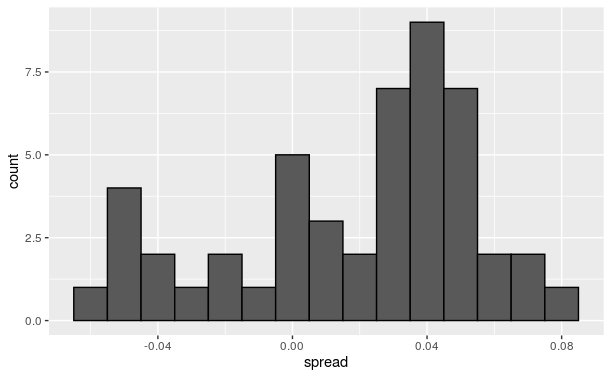

```r
polls %>%
  ggplot(aes(spread)) +
  geom_histogram(color="black", binwidth = .01)
```

The data does not appear to be normally distributed and the standard error appears to be larger than 0.007.

### 16.1.2 Pollister bias

```r
polls %>% group_by(pollster) %>% summarize(n())
```

| pollster | n() |
| --- | --- |
| ABC News/Washington Post | 7 |
| Angus Reid Global | 1 |
| CBS News/New York Times | 2 |
| Fox News/Anderson Robbins Research/Shaw & Company Research | 2 |
| IBD/TIPP | 8 |
| Insights West | 1 |
| Ipsos | 6 |
| Marist College | 1 |
| Monmouth University | 1 |
| Morning Consult | 1 |

[output cut: 5 more lines]

First, consider that the standard error predicted by theory for each poll:

```r
polls %>% group_by(pollster) %>%
  filter(n() >= 6) %>%
  summarize(se = 2 * sqrt(p_hat * (1-p_hat) / median(samplesize)))
```

| pollster | se |
| --- | --- |
| ABC News/Washington Post | 0.02654389 |
| IBD/TIPP | 0.03332069 |
| Ipsos | 0.02251943 |
| The Times-Picayune/Lucid | 0.01963986 |
| USC Dornsife/LA Times | 0.01831826 |

is between 0.018 and 0.033. However, there appears to be differences across the polls.

The theory we learned says nothing about different pollsters producing polls with different expected values. All the polls should have the same expected value. FiveThirtyEight refers to these differences as “house effects”. We also call them pollster bias.

## 16.2 Data-driven models

Last reported result before the election:

```r
one_poll_per_pollster <- polls %>% group_by(pollster) %>%
  filter(enddate == max(enddate)) %>%
  ungroup()
```

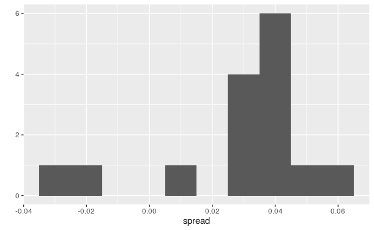

```r
qplot(spread, data = one_poll_per_pollster, binwidth = 0.01)
```

Using the urn model theory to combine these results might not be appropriate due to the pollster effect. Instead, we will model this spread data directly.

Rather than 0s (Republicans) and 1s (Democrats), our urn now contains poll results from all possible pollsters. We assume that the expected value of our urn is the actual spread $d=2p-1$.

Because instead of 0s and 1s, our urn contains continuous numbers between -1 and 1, the standard deviation of the urn is no longer $\sqrt{{p(1-p)}}$.

Rather than voter sampling variability, the standard error now includes the pollster-to-pollster variability. Our new urn also includes the sampling variability from the polling.

Standard deviation; now an unknown parameter. The Greek symbol σ is used to represent this parameter.

In summary, we have two unknown parameters: the expected value d and the standard deviation σ.

Our task: estimate d. The CLT might still work in this situation; average of independent random variables.

For a large enough sample size N, the probability distribution of the sample average $\bar{X}$ is approximately normal with μ and standard error $σ/\sqrt{N}$.

Problm: we don’t know $\sigma$. We can estimate $\sigma$ with Sample Standard Deviation

We now divide by $N-1$ : makes better estimate of $\sigma$.

function sd computes sample standard deviation

```r
sd(one_poll_per_pollster$spread)
```

```
[1] 0.02419369
```

We’re ready to form a new confidence interval:

```r
results <- one_poll_per_pollster %>%
  summarize(avg = mean(spread),
            se = sd(spread) / sqrt(length(spread))) %>%
  mutate(start = avg - 1.96 * se,
         end = avg + 1.96 * se)
round(results * 100, 1)
```

| avg | se | start | end |
| --- | --- | --- | --- |
| 2.9 | 0.6 | 1.7 | 4.1 |

Our confidence interval is wider; since it incorporates the pollster variability.

Are we now ready to declare a probability of Clinton winning the popular vote? Not yet. In our model $d$ is a fixed parameter so we can’t talk about probabilities. To provide probabilities, we will need to learn about Bayesian statistics.

## 16.3 Exercises

Heights dataset;

```r
library(dslabs)
data(heights)
x <- heights %>% filter(sex == "Male") %>%
  pull(height)
```

1. Mathematically speaking, x is our population. Using the urn analogy, we have an urn with the values of x in it. What are the average and standard deviation of our population?

```r
mean(x)
```

```
[1] 69.31475
```

```r
sd(x)
```

```
[1] 3.611024
```

2. Call the population average computed above μ and the standard deviation σ. Now take a sample of size 50, with replacement, and construct an estimate for μ and σ.

```r
N <- 50
X <- sample(x, N, replace = TRUE)
mu <- mean(X)
sigma <- sd(X)
mu
```

```
[1] 69.36258
```

```r
sigma
```

```
[1] 3.546353
```

3. What does the theory tell us about the sample average $\bar{X}$ and how it is related to μ?

A. It is practically identical to μ. **B. It is a random variable with expected value μ and standard error $σ/\sqrt{N}$.** C. It is a random variable with expected value μ and standard error σ. D. Contains no information.

4. So how is this useful? We are going to use an oversimplified yet illustrative example. Suppose we want to know the average height of our male students, but we only get to measure 50 of the 708. We will use $\bar{X}$ as our estimate. We know from the answer to exercise 3 that the standard estimate of our error $\bar{X}$−μ is $σ/\sqrt{N}$. We want to compute this, but we don’t know σ. Based on what is described in this section, show your estimate of σ.

```r
sigma
```

```
[1] 3.546353
```

5. Now that we have an estimate of σ, let’s call our estimate s. Construct a 95% confidence interval for μ.

```r
se <- sd(X)/sqrt(N)
interval <- c(qnorm(0.025, mean(X), se), qnorm(0.975, mean(X), se))
interval
```

```
[1] 68.37960 70.34556
```

6. Now run a Monte Carlo simulation in which you compute 10,000 confidence intervals as you have just done. What proportion of these intervals include μ?

```r
N <- 50
B <- 10000
se <- sd(X)/sqrt(N)
sim <- replicate(B, {
  X <- sample(x, N, replace=TRUE)
  mean(x)<=qnorm(0.975, mean(X), se) & mean(x) >= qnorm(0.025, mean(X), se)})
mean(sim)
```

```
[1] 0.9471
```

7. In this section, we talked about pollster bias. We used visualization to motivate the presence of such bias. Here we will give it a more rigorous treatment. We will consider two pollsters that conducted daily polls. We will look at national polls for the month before the election.

```r
data(polls_us_election_2016)
polls <- polls_us_election_2016 %>%
  filter(pollster %in% c("Rasmussen Reports/Pulse Opinion Research",
                         "The Times-Picayune/Lucid") &
           enddate >= "2016-10-15" &
           state == "U.S.") %>%
  mutate(spread = rawpoll_clinton/100 - rawpoll_trump/100)
```

We want to answer the question: is there a poll bias? Make a plot showing the spreads for each poll.

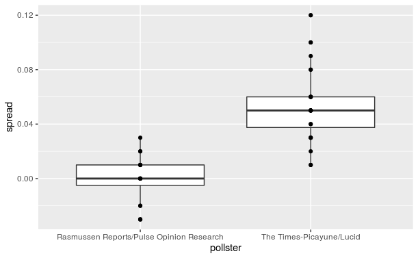

```r
polls %>% ggplot(aes(pollster, spread)) +
  geom_boxplot() +
  geom_point()
```

8. The data does seem to suggest there is a difference. However, these data are subject to variability. Perhaps the differences we observe are due to chance.

The urn model theory says nothing about pollster effect. Under the urn model, both pollsters have the same expected value: the election day difference, that we call d.

To answer the question “is there an urn model?”, we will model the observed data $Y_{i,j}=d+b_i+ε_{i,j}$ in the following way:

with i=1,2 indexing the two pollsters, $b_i$ the bias for pollster i and $ε_{i,j}$ poll to poll chance variability. We assume the ε are independent from each other, have expected value 0 and standard deviation $σ_i$ regardless of j.

Which of the following best represents our question?

A. Is ε_{i,j}= 0? B. How close are the Y_{i,j} to d? **C. Is $b_1$ different with $b_2$?** D. Are $b_1=0$ and $b_2=0?$

9. In the right side of this model only $ε_{i,j}$ is a random variable. The other two are constants. What is the expected value of $Y_{1,j}$?

$E[Y_{1,j}]$ = $E[d + b_1 + ε_{i,j}]$$ = d+b_1+$E[ε_{i,j}]$ = d + $b_1$

10. Suppose we define $\bar{Y}_1$ as the average of poll results from the first poll, $Y_{1,1},...,Y_{1,N_1}$ with $N_1$ the number of polls conducted by the first pollster:

```r
polls %>%
  filter(pollster=="Rasmussen Reports/Pulse Opinion Research") %>%
  summarize(N_1 = n())
```

| N_1 |
| --- |
| 16 |

What is the expected values $\bar{Y}_1$?

$d + b_1$

11. What is the standard error of $\bar{Y}_1$ ?

$\sigma_1/\sqrt{N_1}$

12. Suppose we define $\bar{Y}_2$ as the average of poll results from the first poll, $Y_{2,1}, ... ,Y_{2,N_2}$ with $N_2$ the number of polls conducted by the first pollster. What is the expected value $\bar{Y}_2$?

$d + b_2$

13. What is the standard error of $\bar{Y}_2$ ?

$\sigma_2/\sqrt{N_2}$

14. Using what we learned by answering the questions above, what is the expected value of $\bar{Y}_{2} - \bar{Y}_1$?

$E[\bar{Y}_{2} - \bar{Y}_1] = E[\bar{Y}_{2}] - E[\bar{Y}_1] = (d + b_2) - (d + b_1) = b_2 - b1$

15. Using what we learned by answering the questions above, what is the standard error of $\bar{Y}_{2} - \bar{Y}_1$?

16. The answer to the question above depends on $\sigma_1$ and $\sigma_2$, which we don’t know. We learned that we can estimate these with the sample standard deviation. Write code that computes these two estimates.

```r
polls %>% group_by(pollster) %>%
  summarize(s = sd(spread))
```

| pollster | s |
| --- | --- |
| Rasmussen Reports/Pulse Opinion Research | 0.01768945 |
| The Times-Picayune/Lucid | 0.02678078 |

17. What does the CLT tell us about the distribution of $\bar{Y}_2 - \bar{Y}_1$?

A. Nothing because this is not the average of a sample. B. Because the $Y_{ij}$ are approximately normal, so are the averages. **C. Note that $\bar{Y}_2$ and $\bar{Y}_1$ are sample averages, so if we assume $N_2$ and $N_1$ are large enough, each is approximately normal. The difference of normals is also normal.** D. The data are not 0 or 1, so CLT does not apply.

18. We have constructed a random variable that has expected value $b_2 - b_1$, the pollster bias difference. If our model holds, then this random variable has an approximately normal distribution and we know its standard error. The standard error depends on $\sigma_1$ and $\sigma_2$, but we can plug the sample standard deviations we computed above. We started off by asking: is $b_2 - b_1$ different from 0? Use all the information we have learned above to construct a 95% confidence interval for the difference $b_2$ and $b_1$.

```r
res <- polls %>% group_by(pollster) %>%
  summarize(avg = mean(spread), s = sd(spread), N = n())
estimate <- res$avg[2] - res$avg[1]
se_hat <- with(res, sqrt(s[2]^2/N[2] + s[1]^2/N[1]))
estimate + c(-1,1)*qnorm(0.975)*se_hat
```

```
[1] 0.03851031 0.06607302
```

19. The confidence interval tells us there is relatively strong pollster effect resulting in a difference of about 5%. Random variability does not seem to explain it. We can compute a p-value to relay the fact that chance does not explain it. What is the p-value?

```r
2*(1 - pnorm(estimate/se_hat, 0, 1))
```

```
[1] 1.030287e-13
```

20. The statistic formed by dividing our estimate of $b_2-b_1$ by its estimated standard error:

is called the t-statistic. Now notice that we have more than two pollsters. We can also test for pollster effect using all pollsters, not just two. The idea is to compare the variability across polls to variability within polls. We can actually construct statistics to test for effects and approximate their distribution. The area of statistics that does this is called Analysis of Variance or ANOVA. We do not cover it here, but ANOVA provides a very useful set of tools to answer questions such as: is there a pollster effect?

For this exercise, create a new table:

```r
polls <- polls_us_election_2016 %>%
  filter(enddate >= "2016-10-15" &
           state == "U.S.") %>%
  group_by(pollster) %>%
  filter(n() >= 5) %>%
  mutate(spread = rawpoll_clinton/100 - rawpoll_trump/100) %>%
  ungroup()
```

Compute the average and standard deviation for each pollster and examine the variability across the averages and how it compares to the variability within the pollsters, summarized by the standard deviation.

```r
polls %>% group_by(pollster) %>%
  summarize(avg = mean(spread), sd = sd(spread))
```

| pollster | avg | sd |
| --- | --- | --- |
| ABC News/Washington Post | 0.037333333 | 0.033904628 |
| CVOTER International | 0.027895455 | 0.017975499 |
| Google Consumer Surveys | 0.030280000 | 0.018476390 |
| Gravis Marketing | 0.016000000 | 0.015165751 |
| IBD/TIPP | 0.001047619 | 0.016832933 |
| Ipsos | 0.055272727 | 0.019464698 |
| Morning Consult | 0.041428571 | 0.014638501 |
| Rasmussen Reports/Pulse Opinion Research | 0.000625000 | 0.017689451 |
| The Times-Picayune/Lucid | 0.052916667 | 0.026780779 |
| USC Dornsife/LA Times | -0.021320833 | 0.020661474 |

[output cut: 1 more lines]